# Module 2, Assignment 3

Ellen Bledsoe

2022-10-04

# Assignment Details

### Purpose

The goal of this assignment is to practice developing successful workflows to get from the starting data to a plot.

### Task

Write R code which produces the correct answers and reflect on workflow.

### Criteria for Success

- Code is within the provided code chunks
- Code is commented with brief descriptions of what the code does
- Code chunks run without errors
- Code produces the correct result
  - Code that produces the correct answer will receive full credit
  - Code attempts with logical direction will receive partial credit
- Written answers address the questions in sufficient detail

### Due Date

October 11 at midnight MST

# Assignment Questions

Our goal for this assignment is to start with a data frame of data, summarize the data in constructive ways, and plot the data to answer some questions. To get from point a to point b to point c requires some planning.

In this assignment, we will make a plan, execute how we would actually go about the process, and then evaluate how well our original plan matches with the path we actually used.

## Data Summary

The aquaculture scientists on Team Antarctica have been working on developing a new diet for tilapia based on soy-protein, and they are interested in whether incorporating this into fish diets will result in faster growth rates. They also want to know if those growth rates are related to average tank temperature. They’ve provided us with this data to analyze.

First, let’s take a look at the data we will be using for the assignment. Use the `head` function to get an idea of what the data look like.

1. As always, we start by loading the `tidyverse`.

```r
library(tidyverse)
```

2. Next, we need to load in our tilapia growth dataset. Call the data frame `growth`. Then use both the `head` and `tail` functions to take a look at the data.

```r
growth <- read_csv("../data/tilapia_growth.csv")
head(growth)
```

```
## # A tibble: 6 × 5
##   tank_id fish_id perc_soy_protein day_30_weight avg_tank_temp
##     <dbl>   <dbl>            <dbl>         <dbl>         <dbl>
## 1       1       1              0.2         334.           77.2
## 2       1       2              0.2         198.           77.2
## 3       1       3              0.2         315.           77.2
## 4       1       4              0.2         316.           77.2
## 5       1       5              0.2          89.4          77.2
## 6       1       6              0.2          74.7          77.2
```

```r
tail(growth)
```

```
## # A tibble: 6 × 5
##   tank_id fish_id perc_soy_protein day_30_weight avg_tank_temp
##     <dbl>   <dbl>            <dbl>         <dbl>         <dbl>
## 1      16     315              0.8         1228.          76.1
## 2      16     316              0.8          630.          76.1
## 3      16     317              0.8          508.          76.1
## 4      16     318              0.8          443.          76.1
## 5      16     319              0.8          495.          76.1
## 6      16     320              0.8         1078.          76.1
```

3. Before we can plan any strategy, we need to understand the data that we have.

```r
growth_by_treatment <- growth %>%
  group_by(perc_soy_protein) %>%
  summarize(mean_30weight = mean(day_30_weight),
            sd_30weight = sd(day_30_weight))
growth_by_treatment
```

```
## # A tibble: 4 × 3
##   perc_soy_protein mean_30weight sd_30weight
##              <dbl>         <dbl>       <dbl>
## 1              0.2          276.        170.
## 2              0.4          441.        249.
## 3              0.6          618.        209.
## 4              0.8          829.        246.
```

```r
growth_by_tank <- growth %>%
  group_by(tank_id) %>%
  summarise(mean = mean(day_30_weight))
growth_by_tank
```

```
## # A tibble: 16 × 2
##    tank_id  mean
##      <dbl> <dbl>
##  1       1  200.
##  2       2  345.
##  3       3  325.
##  4       4  234.
##  5       5  481.
##  6       6  413.
##  7       7  420.
##  8       8  450.
##  9       9  602.
## 10      10  596.
## 11      11  644.
## 12      12  631.
## 13      13  870.
## 14      14  739.
## 15      15  909.
## 16      16  797.
```

```r
growth <- growth %>%
  mutate(temp_cutoff = if_else(avg_tank_temp >= 75, "above", "below"))


growth_by_temp_and_treatment <- growth %>%
  group_by(perc_soy_protein, temp_cutoff) %>%
  summarise(mean = mean(day_30_weight))
growth_by_temp_and_treatment
```

```
## # A tibble: 8 × 3
## # Groups:   perc_soy_protein [4]
##   perc_soy_protein temp_cutoff  mean
##              <dbl> <chr>       <dbl>
## 1              0.2 above        272.
## 2              0.2 below        279.
## 3              0.4 above        448.
## 4              0.4 below        420.
## 5              0.6 above        620.
## 6              0.6 below        617.
## 7              0.8 above        833.
## 8              0.8 below        824.
```

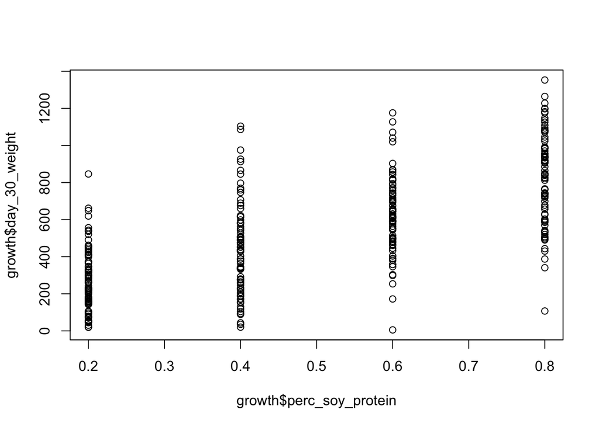

```r
plot(x = growth$perc_soy_protein, y = growth$day_30_weight)
```

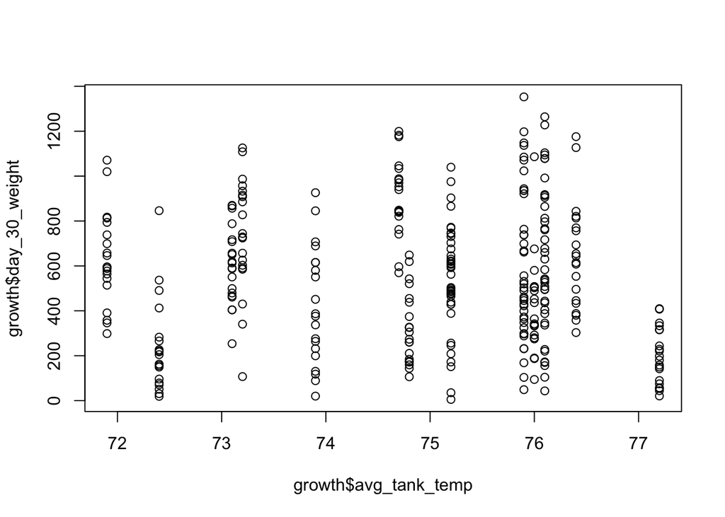

```r
plot(x = growth$avg_tank_temp, y = growth$day_30_weight)
```